# Gumbel-Softmax Trick

Ying Fu (dhlsfy@163.com) School of Business Administration, South China University of Technology Date: 20 Jan. 2021

## Introduction

Let $z$ be a categorical variable with class probabilities $\mathbf{\pi} = [\pi_1,\pi_2,\cdots,\pi_k]$.  
How do we sample from a categorical probability distribution? The simplest method is using roulette wheel selection via `np.random.choice`. However, this sampling process cannot be embedded into neural network as it is not differentiable and backpropagation will fail. Eric Jiang etc. proposed [Gumbel-Softmax distribution](https://arxiv.org/abs/1611.01144) in 2016, a continuous approximation of samples from a categorical distribution, which can be embedded into neuroal network to generate samples.

This blog will cover the following topics with Python codes  
1). introduce the Gumbel distribution  
2). compare different sampling methods for categorical variables  
3). prove the Gumbel-max trick  
4). explain the Gumbel-softmax trick

## 1. What is Gumbel distribution

> This distribution might be used to represent the distribution of the maximum level of a river in a particular year if there was a list of maximum values for the past several years.

**Example**: Suppose that the level of a river each year follows normal distribution with mean equals to 10 and standard deviration equals to 2 and each day 1000 measures are recorded. We have totally 10000 days of records. If we extract the maximum level of a river each day, then the daily maximum level of a river would follow a Gumbel distribution.

```
shape of record (10000, 1000)
shape of daily_maximum (10000,)
```

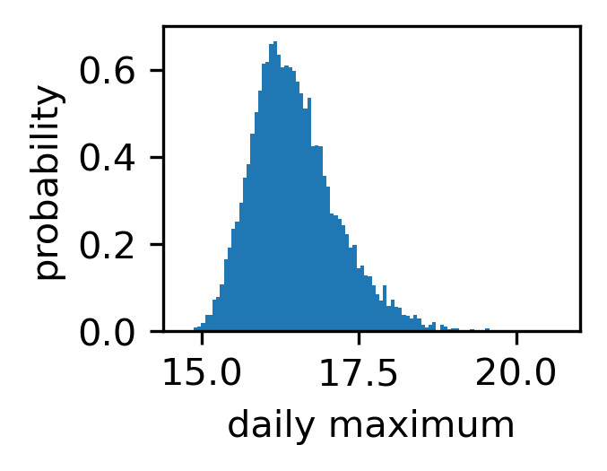

```python
import numpy as np
np.random.seed(5)
import matplotlib.pyplot as plt


mean_level = 10
std_level = 2
measures_per_day = 1000
total_days = 10000

# generate #total_days normal distribution
record = np.random.normal(loc = mean_level,scale = std_level,size = (total_days,measures_per_day) )
print("shape of record",record.shape)

maximum = np.max(record,axis = 1)
print("shape of daily_maximum",maximum.shape)

# plot histgram of daily_maximum
plt.figure(figsize = (2,1.5))
plt.hist(maximum,density=True, bins=100)
plt.xlabel("daily maximum")
plt.ylabel("probability")
plt.show()
```

Let's check whether `daily_maximum` follows gumbel distribution or not by using `curve_fit`

```
loc: 16.1711, scale: 0.5752
```

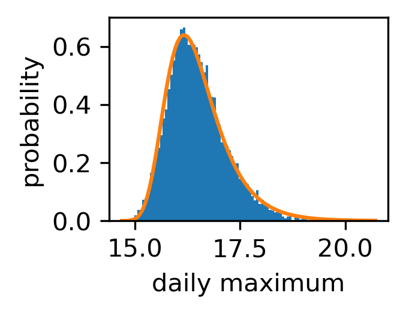

```python
from scipy.optimize import curve_fit

def gumbel_pdf(x, loc, scale):
    z = (x - loc) / scale
    return np.exp(-z - np.exp(-z)) / scale


def curveFit(maximum):
    # probs: the values of the histogram bins
    # bins: The edges of the bins. Length nbins + 1
    plt.figure(figsize = (2,1.5))
    probs, bins, patches= plt.hist(maximum, density=True, bins=100)
    plt.xlabel("daily maximum")
    plt.ylabel("probability")

    # curve_fit(f,xdata,ydata)
    (loc, scale),_ = curve_fit(gumbel_pdf, bins[:-1], probs)
    print("loc: {0}, scale: {1}".format(round(loc,4),round(scale,4)))
    plt.plot(bins, gumbel_pdf(bins, loc, scale))
    plt.show()

curveFit(maximum)
```

We can see that it fits well. The distribution of daily maximum level of a river is Gumbel-distributed.

## 2. Comparisions between different sampling methods for categorical variables

We conduct experiments to compare different sampling methods for categorical variables.

Let's first generate a categorical distribution with 7 categories, $0,1,2,\cdots 6$ and random probabilities. We plot its probability mass function using bar chart.

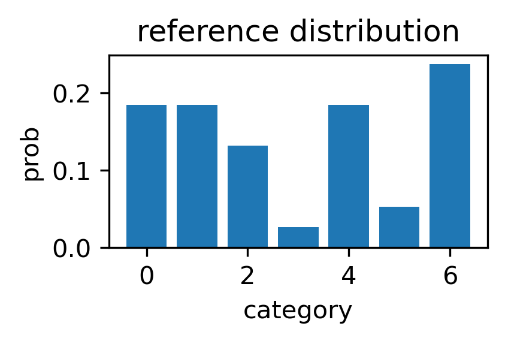

```python
n_categories = 7
categories = np.arange(n_categories)

probs = np.random.randint(low = 1, high = 10, size = n_categories)
probs = probs/sum(probs)  # probability for each category

plt.figure(figsize = (3,2))
plt.bar(categories,probs)
plt.xlabel("category")
plt.ylabel("prob")
plt.title("reference distribution")
plt.tight_layout()
plt.show()
```

We first implement the [Kullback–Leibler divergence](https://en.wikipedia.org/wiki/Kullback%E2%80%93Leibler_divergence) function KL, that measures the difference between two distributions.

> For discrete probability distributions ${\displaystyle P}$ and ${\displaystyle Q}$ defined on the same probability space, ${\displaystyle {\mathcal {X}}}$, the relative entropy from ${\displaystyle Q}$ to ${\displaystyle P}$ is defined to be: $$ {\displaystyle D_{\text{KL}}(P\parallel Q)=\sum _{x\in {\mathcal {X}}}P(x)\log \left({\frac {P(x)}{Q(x)}}\right).} $$

```python
def KL(P,Q):

    EPISION = 0.00001 # to avoid taking the log of zero

    P = P + EPISION
    Q = Q + EPISION

    return np.sum(P*np.log(P/Q))
```

Different sampling methods are:  
1). **Random choice based on the probability distribution**

2). **Sample with gumbel distributed noise**
Let $z$ be a categorical variable with class probabilities $\mathbf{\pi} = [\pi_1,\pi_2,\cdots,\pi_k]$ $$ z = \underset{ i \in \{1,\cdots,k\} }{\operatorname{argmax}} (\log(\pi_i) + G_i) $$ where $G_1,G_2,\cdots, G_k$ are i.i.d samples drawn from Gumbel(0,1). If we don't have access to a Gumbel random variate generator, we can also use $−\log(−\log(U(0,1))$ through [inverse transform sampling](https://en.wikipedia.org/wiki/Inverse_transform_sampling)

3). **Sample with normal distributed noise**  
Just replace the Gumbel distribution noise in 2) to normal distribution noise.

```
KL divergency between byRandomChoice and reference distribution is: 0.00092
KL divergency between byGumbelNoise and reference distribution is: 0.00563
KL divergency between byNormalNoise and reference distribution is: 0.06359
```

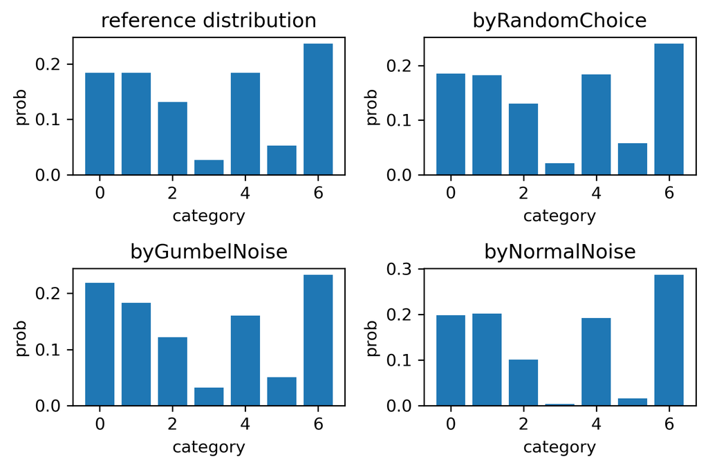

```python
from collections import Counter
np.random.seed(6)

logits = np.log(probs)

def countEachCategory(samples):
    '''
    Count the frequency of each category and return a sorted dict (ascending  = True)
    '''
    w = dict(Counter(samples))
    total = sum(list(w.values()))
    a = {k: v / total for k, v in w.items()}

    return dict(sorted(a.items()))


def byRandomChoice(sampleCount = 1000):
    '''
    Sampling rule: random choice based on population distribution
    '''
    samples =  np.random.choice(n_categories, size = sampleCount, replace = True, p = probs)

    return samples


def byGumbelNoise(sampleCount = 1000):
    '''
    Sampling rule: argmax(logits + gumbel noise)
    '''
    samples = []
    for i in range(sampleCount):
        # noise = np.random.gumbel(size = len(logits))  # through numpy.gumbel function
        noise = -np.log(-np.log(np.random.uniform(size = len(logits)))) # through Inverse transform sampling
        samples.append(np.argmax(logits + noise))
    return samples


def byNormalNoise(sampleCount = 1000):
    '''
    Sampling rule: argmax(logits + normal noise)
    '''
    samples = []
    for i in range(sampleCount):
        noise = np.random.normal(loc=0.0, scale=1.0, size=len(logits))
        samples.append(np.argmax(logits + noise))
    return samples


def plotSampleTechniques(SampleTechList = [byRandomChoice,byGumbelNoise,byNormalNoise]):

    lenPlot = len(SampleTechList) + 1
    ncols = 2
    if lenPlot % ncols == 0:
        nrows = int(lenPlot / 2)
    else:
        nrows = int(lenPlot / 2) + 1

    plt.figure(figsize = (6,4))

    plt.subplot(nrows,ncols,1)
    plt.bar(categories,probs)
    plt.xlabel("category")
    plt.ylabel("prob")
    plt.title("reference distribution")

    for (i,sampleTech) in enumerate(SampleTechList):

        a = countEachCategory(sampleTech())

        probs_sampling = list(a.values())
        kl = KL(np.array(probs), np.array(probs_sampling))
        print("KL divergency between {0} and reference distribution is: {1}".format(str(sampleTech.__name__),round(kl,5)))

        plt.subplot(nrows,ncols,i+2)
        plt.bar(a.keys(), a.values())
        plt.xlabel("category")
        plt.ylabel( "prob")
        plt.title(str(sampleTech.__name__))
        plt.tight_layout()

plotSampleTechniques()
```

The probability distribution of samples created by random choice is very close to $\pi$ with KL as small as 0.00092. Using argmax with Gumbel noise produces distribuitons very similar to the reference with KL as small as 0.00563. This method is called the **Gumbel-max trick**.

Replace Gumble noise by other type of noise such as normal, will not work well, the KL is 0.06359, substantially worse than that of Gumbel noise.

## 3. Proof of Gumbel-max trick

Recall that Gumbel distribution with unit scale and location parameter $\mu$ has the following PDF:
$$ \begin{align*} f(z\,;\,\mu) &= e^{-(z-\mu) - e^{-(z-\mu)}} \end{align*} $$

The CDF is: $$ \begin{align*} F(z\,;\,\mu) &= e^{-e^{-(z-\mu)}}\end{align*} $$

Denote $x_k =log(\pi_k)$, imagine that the $k-th$ of our Gumbels, with location $x_k$, resulted in an outcome $z_k$, then, $z_k = x_k + G_i$. The probability that all of the other $z_{k'\neq k}$ are less than this is

\begin{align*} \Pr(z_k \text{ is largest}\,|\, z_k, \{x_{k'}\}^K_{k'=1}) &=\Pr(z_k>\max_{k'\neq k} z_{k'})\\ &= \Pr(\max_{k'\neq k} z_{k'}< z_k) \\ &= \prod_{k'\neq k}\Pr(Z_{k'}\leq z_k;x_{k'})\\ &= \prod_{k'\neq k}e^{-e^{-(z_k-x_{k'})}} \end{align*}

We know the marginal distribution over $z_k$ and we need to integrate it out to find the overall probability:

\begin{align*} \Pr(z_k \text{ is largest}\,|\{x_{k'}\}^K_{k'=1}) &= \int^{\infty}_{-\infty}f(z_k,x_k) \Pr(z_k \text{ is largest}\,|\, z_k, \{x_{k'}\}^K_{k'=1}){dz_k}\\ &= \int^{\infty}_{-\infty}e^{-(z-\mu) - e^{-(z-\mu)}}\prod_{k'\neq k}e^{-e^{-(z_k-x_{k'})}}{dz_k}\\ &= \int^{\infty}_{-\infty}e^{-(z_k-x_k)-e^{(z_k-x_k)}+\sum_{k'\neq k}-e^{(-z_k-x_{k'})}}{dz_k}\\ &= \int^{\infty}_{-\infty}e^{(x_k-z_k)-\sum\limits_{k'=1}^{k}e^{-(z_k-x_{k'})}}{dz_k}\\ &= \int^{\infty}_{-\infty}e^{x_k}e^{-z_k-e^{-z_k}\sum\limits_{k'=1}^{k}e^{x_{k'}}}{dz_k}\\ &= e^{x_k}\int^{\infty}_{-\infty}e^{-z_k-Me^{-z_k}}{dz_k}\\ \end{align*}

where $M = \sum\limits_{k'=1}^{k}e^{x_{k'}}$

Let $-z_k = y$, then $dz_x = -dy$ $$ \begin{align*} \int e^{-z_k-Me^{-z_k}}{dz_k} & = \int -e^y e^{-Me^y}dy\\ \end{align*} $$ Let $x=e^y$, then $y=\ln x, dy = \frac{1}{x}dx$ $$ \begin{align*} \int e^{-z_k-Me^{-z_k}}{dz_k} & = \int -e^y e^{-Me^y}dy\\ & = \int -x e^{-Mx}\frac{1}{x}dx\\ & = \int -e^{-Mx} dx\\ & = \frac{1}{M}e^{-Mx}\\ & = \frac{1}{M}e^{-Me^{-z_k}} \end{align*} $$ So, \begin{align*} \Pr(z_k \text{ is largest}\,|\{x_{k'}\}^K_{k'=1}) &= e^{x_k}\int^{\infty}_{-\infty}e^{-z_k-Me^{-z_k}}{dz_k}\\ & = e^{x_k} \frac{1}{M}e^{{-M}e^{-z_k}} \Bigg|_{-\infty}^{\infty}\\ & = e^{x_k} \frac{1}{M}e^{{-M}e^{-\infty}}-e^{x_k} \frac{1}{M}e^{{-M}e^{\infty}} \\ & = e^{x_k} \frac{1}{M}(1-0) \\ & = \frac{e^{x_k}}{M}\\ & = \frac{e^{x_k}}{\sum\limits_{k'=1}^{k}e^{x_{k'}}}\\ & = \frac{\pi_k}{\sum\limits_{k'=1}^{k}\pi_{k'}}\\ & = \pi_k \end{align*} It is exactly the original probability.

## 4. Gumbel-softmax trick

So far, we have illustrated that the Gumbel-max trick, by adding noise to the logits then taking the argmax of the resulting vector, provides a simple and efficient way to draw samples $y$ from a categorical distribution with class probabilities $\pi$. However, $\arg\max$ is not differentiable. So softmax function can be a continuous, differentiable approximation to $\arg\max$, this is called Gumbel-softmax trick.

$$ y_{i}=\frac{\exp \left(\left(\log \left(\pi_{i}\right)+g_{i}\right) / \tau\right)}{\sum_{j=1}^{k} \exp \left(\left(\log \left(\pi_{j}\right)+g_{j}\right) / \tau\right)} \quad \text { for } i=1, \ldots, k $$

Where $\tau$ is a temperature parameter.

```
argmax logits + gumbel noise  6
one-hot encoding through argmax:  [0. 0. 0. 0. 0. 0. 1.]
one-hot encoding through softmax: [0.1495 0.1429 0.1424 0.1232 0.1551 0.1285 0.1584] with temp: 10:
one-hot encoding through softmax: [0.1714 0.1086 0.1055 0.0248 0.2475 0.0375 0.3047] with temp: 1:
one-hot encoding through softmax: [0.0028 0.     0.     0.     0.1109 0.     0.8863] with temp: 0.1:
one-hot encoding through softmax: [0. 0. 0. 0. 0. 0. 1.] with temp: 0.01:
```

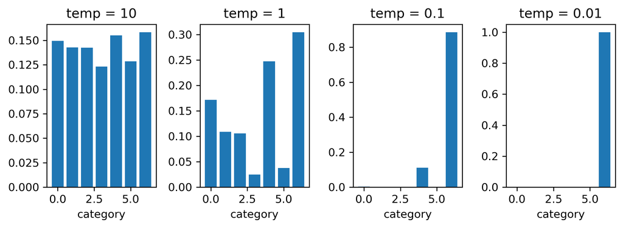

```python
from scipy.special import softmax
np.random.seed(0)


def softmaxWithTemp(v,temp):
    '''
    v: array,概率向量
    '''
    EPSILON = 10e-16 # to avoid taking the log of zero
    v = v + EPSILON
    preds = v / temp
    exp_preds = np.exp(preds)
    preds = exp_preds / np.sum(exp_preds)

    return preds


def gumbelSoftmax(logits = logits,tempList = [10,1,0.1,0.01]):

    noise = np.random.gumbel(loc=0.0, scale=1.0, size = len(logits))
    v = logits + noise
    a = np.argmax(v)
    print("argmax logits + gumbel noise ", a)
    b = np.zeros((len(v)))
    b[a] = 1
    print("one-hot encoding through argmax: ",b)  # 通过 argmax 计算得到的 one-hot encoding

    plt.figure(figsize = (8,3))
    for (i,temp) in enumerate(tempList):
        preds = softmaxWithTemp(v=v,temp = temp)
        print("one-hot encoding through softmax: {0} with temp: {1}: ".format(np.round(preds,4),temp)) # 用 softmax对 argmax进行近似

        plt.subplot(1,len(tempList),i+1)
        plt.bar(categories,preds)
        plt.xlabel("category")
        plt.title("temp = {0}".format(temp))
        plt.tight_layout()

gumbelSoftmax()
```

We can see that $\tau$ controls how closely the new samples approximate discrete, one-hot vectors. As $\tau$ approaches to 0, the softmax computation approaches to argmax, samples from the Gumbel-Softmax distribution becomes one-hot. As $\tau$ approaches to infinity, samples from the Gumbel-Softmax distribution becomes uniform.

### Reference

[1] Jang E, Gu S, Poole B. Categorical reparameterization with gumbel-softmax[J]. arXiv preprint arXiv:1611.01144, 2016  
[2] http://amid.fish/humble-gumbel  
[3] https://lips.cs.princeton.edu/  
[4] https://www.cnblogs.com/initial-h/p/9468974.html